# A Climate Change Model

ESM 204: Homework #4

Bobby Miyashiro & Keene Morrow

5/27/2020

ESM 204: Homework #4 (A Climate Change Model) Professor Christopher Costello Due May 27, 8:00 am

This problem set asks you to build a climate-economy model with risk and discounting and to conduct sensitivity analysis on it. Hint: I strongly recommend using R and building “functions” for each of the equations you see below. Under BAU, let tau(t) be the temperature in year t (t = 0, 1, …, 200) relative to the temperature at time 0. Suppose

tau(t) = min(Tt/100, T) (1)

```r
# Relative temperature change by year
rel_temp_t <- function(T, year){
  temp_t = ifelse(year <= 100, year * (T / 100), T)
  return(temp_t)
}

# I'm not sure I follow the provided equation, but here it is anyway - KM
tau_t <- function(Tt, T){
  rel_temp = min(Tt / 100, T)
  return(rel_temp)
}
```

Where T is the BAU temperature increase at year 100. For example, if T = 5 then the temperature increases over time (linearly) until year 100, when it flattens out at 5.

The hotter it is, the more it affects daily life and it starts to eat away at economic activity. Let K(t) be the fraction of economic activity that is retained in a year if the temperature is tau (t), given by

K(t) = exp(−beta * tau(t)^2) (2)

```r
# Fraction of economic activity retained
K_t <- function(beta, tau_t){
  K_t = exp(-beta * tau_t^2)
  return(K_t)
}
```

Economic activity (“consumption”) grows over time at rate g, but is reduced by K (see above), so total consumption at time t is:

C(t) = K(t)exp(gt) (3)

```r
# Consumption retained
C_t <- function(K_t, g, t){
  C_t <- K_t * exp(g*t)
  return(C_t)
}
```

Society’s utility from consumption is given by the function

U(C) = ( C^(1 − eta) ) / (1 - eta) (4)

```r
# Utility from consumption
U_C <- function(C, eta){
  U_C = (C ^(1 - eta)) / (1 - eta)
  return(U_C)
}
```

For some analyses below, you may wish to discount utility to present value. The discount rate is given by the Ramsey Rule:

r = delta + eta * g (5)

```r
ramsey <- function(delta, eta, g){
  r = delta + eta * g
  return(r)
}
```

You will build a climate-economy model using the equations above. Use the following base case parameters for this model: delta = 0.005, eta = 0.5, g = 0.01, beta = 0.05.

```r
delta <- 0.005
eta <- 0.5
# original eta was 0.5
g <- 0.01
# original g was 0.01
beta <- 0.05
# original beta was 0.05
```

1. Plots
1. Plot temperature over time for no climate change (T = 0), with modest climate change (T = 2), and with extreme climate change (T = 8).

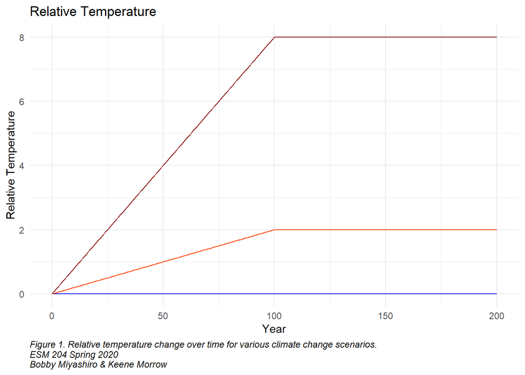

```r
df_plots <- df %>%
  mutate(tau_t_0 = rel_temp_t(0, t),
         tau_t_2 = rel_temp_t(2, t),
         tau_t_8 = rel_temp_t(8, t))

# Plot: Temperature over time

ggplot(data = df_plots) +
  geom_line(aes(x = t,
                y = tau_t_0),
            color = "blue") +
  geom_line(aes(x = t,
                y = tau_t_2),
            color = "orangered") +
  geom_line(aes(x = t,
                y = tau_t_8),
            color = "dark red") +
  labs(title = "Relative Temperature",
       # subtitle = "",
       x = "Year",
       y = "Relative Temperature",
       caption = "Figure 1. Relative temperature change over time for various climate change scenarios.\nESM 204 Spring 2020\nBobby Miyashiro & Keene Morrow") +
  # scale_x_continuous(expand = c(0, 0)) +
  theme_minimal() +
  theme(plot.caption = element_text(hjust = 0, face = "italic"))
```

2. Plot consumption over time for no climate change, modest climate change, and extreme climate change.

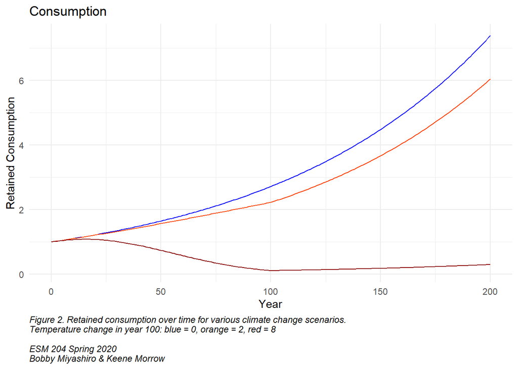

```r
df_plots <- df_plots %>%
  mutate(K_0 = K_t(beta, tau_t_0),
         K_2 = K_t(beta, tau_t_2),
         K_8 = K_t(beta, tau_t_8),
         C_0 = C_t(K_0, g, t),
         C_2 = C_t(K_2, g, t),
         C_8 = C_t(K_8, g, t))

# Plot: Consumption
ggplot(data = df_plots) +
  geom_line(aes(x = t,
                y = C_0),
            color = "blue") +
  geom_line(aes(x = t,
                y = C_2),
            color = "orangered") +
  geom_line(aes(x = t,
                y = C_8),
            color = "dark red") +
  labs(title = "Consumption",
       # subtitle = "",
       x = "Year",
       y = "Retained Consumption",
       caption = "Figure 2. Retained consumption over time for various climate change scenarios.\nTemperature change in year 100: blue = 0, orange = 2, red = 8\n\nESM 204 Spring 2020\nBobby Miyashiro & Keene Morrow") +
  # scale_x_continuous(expand = c(0, 0)) +
  theme_minimal() +
  theme(plot.caption = element_text(hjust = 0, face = "italic"))
```

3. Plot undiscounted utility over time for no climate change, modest climate change, and extreme climate change.

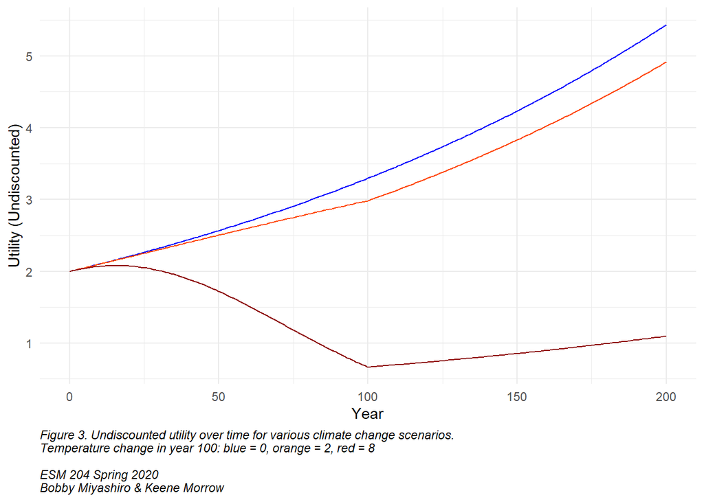

```r
df_plots <- df_plots %>%
  mutate(U_0 = U_C(C_0, eta),
         U_2 = U_C(C_2, eta),
         U_8 = U_C(C_8, eta))

# Plot: undiscounted utility
ggplot(data = df_plots) +
  geom_line(aes(x = t,
                y = U_0),
            color = "blue") +
  geom_line(aes(x = t,
                y = U_2),
            color = "orangered") +
  geom_line(aes(x = t,
                y = U_8),
            color = "dark red") +
  labs(#title = "",
       # subtitle = "",
       x = "Year",
       y = "Utility (Undiscounted)",
       caption = "Figure 3. Undiscounted utility over time for various climate change scenarios.\nTemperature change in year 100: blue = 0, orange = 2, red = 8\n\nESM 204 Spring 2020\nBobby Miyashiro & Keene Morrow") +
  # scale_x_continuous(expand = c(0, 0)) +
  theme_minimal() +
  theme(plot.caption = element_text(hjust = 0, face = "italic"))
```

2. Analysis
1. Suppose T = 4.4. In other words, suppose we know for sure that under BAU, climate change will eventually lead to a 4.4 degree increase in temperature.

```r
PV <- function(x, r, t){
  PV = x/(1+r)^t
  return(PV)
}
```

What is the present value (i.e. discounted) utility over the next 200 years with climate change?

```r
#Present value utility with 4.4 degree increase in temp from climate change
BAU_4.4 <- df %>%
  mutate(tau_t_4.4 = rel_temp_t(4.4, t),
         K_4.4 = K_t(beta, tau_t_4.4),
         C_4.4 = C_t(K_4.4, g, t),
         U_4.4 = U_C(C_4.4, eta),
         PV_4.4 = PV(U_4.4, ramsey(delta, eta, g), t))

PV_BAU_4.4 <- sum(BAU_4.4$PV_4.4)
#PV_BAU_4.4 is 198.661
```

$198.66

What is the present value utility without climate change?

```r
#Present value without utility without climate, hence 0 degree increase
BAU_no_cc <- df %>%
  mutate(tau_t_no_cc = rel_temp_t(0, t),
         K_no_cc = K_t(beta, tau_t_no_cc),
         C_no_cc = C_t(K_no_cc, g, t),
         U_no_cc = U_C(C_no_cc, eta),
         PV_no_cc = PV(U_no_cc, ramsey(delta, eta, g), t))

PV_no_cc <- sum(BAU_no_cc$PV_no_cc)
# PV_no_cc is 255.273
```

$255.27

What is the percentage loss in present value utility from climate change (call this L)?

```r
# Percent loss
L_4.4 <- ((PV_no_cc - PV_BAU_4.4)/PV_no_cc)*100

# L is 22.177
```

22.18% loss

2. Now show how sensitive your calculation of L is to the following parameters: T, g, eta, and beta. To do so, calculate the % change in L that arises from a 10% increase in each of these parameters.

```r
# Present value utility with 4.84 degree increase in temp from climate change
BAU_4.84 <- df %>%
  mutate(tau_t_4.84 = rel_temp_t(4.84, t),
         K_4.84 = K_t(beta, tau_t_4.84),
         C_4.84 = C_t(K_4.84, g, t),
         U_4.84 = U_C(C_4.84, eta),
         PV_4.84 = PV(U_4.84, ramsey(delta, eta, g), t))

PV_BAU_4.84 <- sum(BAU_4.84$PV_4.84)
# PV_BAU_4.84

# Percent loss
L_4.84 <- ((PV_no_cc - PV_BAU_4.84)/PV_no_cc)*100

# L is 25.797 for a 10% increase in T
```

```r
# L with a 10% increase in g is 22.181
# L with a 10% increase in eta is 19.596
# L with a 10% increase in beta is 23.939
```

```r
# Keene's check of the above
# 10% change in T is the same, but the others are off between the two calcs (see L_diff).
# Did you remember to reduce T back to 4.4 for the other calcs?

sen_test <- function(Temp, g, eta, beta, delta = 0.005){
  df <- data.frame(t = seq(0, 200, by = 1))

  T_no_cc <- 0
  g_no_cc <- 0.01
  eta_no_cc <- 0.5
  beta_no_cc <- 0.05
  delta_no_cc <- 0.005

  BAU_no_cc <- df %>%
    mutate(tau_t_no_cc = rel_temp_t(T_no_cc, t),
           K_no_cc = K_t(beta_no_cc, tau_t_no_cc),
           C_no_cc = C_t(K_no_cc, g_no_cc, t),
           U_no_cc = U_C(C_no_cc, eta_no_cc),
           PV_no_cc = PV(U_no_cc, ramsey(delta_no_cc, eta_no_cc, g_no_cc), t))

  PV_no_cc <- sum(BAU_no_cc$PV_no_cc)

  BAU <- df %>%
    mutate(tau_t = rel_temp_t(Temp, t),
           K = K_t(beta, tau_t),
           C = C_t(K, g, t),
           U = U_C(C, eta),
           PV = PV(U, ramsey(delta, eta, g), t))

  PV_BAU <- sum(BAU$PV)

  L = ((PV_no_cc - PV_BAU)/PV_no_cc)*100

  return(L)
}

df_2b <- data.frame(increase = c("none", "T", "g", "eta", "beta")) %>%
  mutate(T_sen = as.numeric(c(4.4, 4.84, 4.4, 4.4, 4.4)),
         g_sen = as.numeric(c(g, g, g * 1.1, g, g)),
         eta_sen = as.numeric(c(eta, eta, eta, eta * 1.1, eta)),
         beta_sen = as.numeric(c(beta, beta, beta, beta, beta * 1.1)))



df_2b <- df_2b %>%
  mutate(L_KM = c(sen_test(df_2b$T_sen[1], df_2b$g_sen[1], df_2b$eta_sen[1], df_2b$beta_sen[1], delta),
                  sen_test(df_2b$T_sen[2], df_2b$g_sen[2], df_2b$eta_sen[2], df_2b$beta_sen[2], delta),
                  sen_test(df_2b$T_sen[3], df_2b$g_sen[3], df_2b$eta_sen[3], df_2b$beta_sen[3], delta),
                  sen_test(df_2b$T_sen[4], df_2b$g_sen[4], df_2b$eta_sen[4], df_2b$beta_sen[4], delta),
                  sen_test(df_2b$T_sen[5], df_2b$g_sen[5], df_2b$eta_sen[5], df_2b$beta_sen[5], delta))) %>%
  mutate(L_BM = c(NA, 25.797, 22.181, 19.596, 23.939),
         L_diff = L_KM - L_BM)

L_no_cc <- df_2b$L_KM[1]

df_2b <- df_2b %>%
  rowwise() %>%
  mutate(L_pct = ((L_KM - L_no_cc)/L_no_cc)*100)
```

| Sensitivity Test: Present Value Utility Lost (L) Adjusted Value | Sensitivity Test: Present Value Utility Lost (L) Percent Change in L |
| --- | --- |
| T | 16.3217768 |
| g | -0.1301919 |
| eta | -20.3563263 |
| beta | 7.9429826 |

3. Back to the original parameters, suppose we could completely prevent climate change from occurring (so T = 0 instead of T = 4.4) but doing so would require giving up a fraction theta of consumption every year for the next 200 years. What is the maximum value of theta society would be willing to endure every year to completely prevent climate change? Call this theta*.

```r
C_t_theta <- function(K_t, g, t, theta = 0){
  C_t <- (K_t * exp(g*t)) * (1 - theta)
  return(C_t)
}


#Find where U becomes negative, holding T at 0 and changing C
#BAU_prevent_cc <- df %>%
#  mutate(
#    tau_t_prevent_cc = rel_temp_t(0, t),
#         K_prevent_cc = K_t(beta, tau_t_prevent_cc),
#         C_prevent_cc = C_t(K_prevent_cc, g, t),
#         U_prevent_cc = U_C(C_prevent_cc - 0.999*C_prevent_cc, eta),
#         PV_prevent_cc = PV(U_prevent_cc, ramsey(delta, eta, g), t))

#PV_prevent_cc <- sum(BAU_prevent_cc$PV_prevent_cc)

# prevent_cc <- full_join(BAU_4.4, BAU_no_cc) %>%
#   mutate(C_difference = C_no_cc - C_4.4)
#
# df_2c <- data.frame(C_0 = BAU_no_cc$C_no_cc,
#                     C_4.4 = BAU_4.4$C_4.4) %>%
#   mutate(diff = C_0 - C_4.4)

T_no_cc <- 0
g_no_cc <- 0.01
eta_no_cc <- 0.5
beta_no_cc <- 0.05
delta_no_cc <- 0.005
theta <- 0

BAU_no_cc <- df %>%
  mutate(tau_t_no_cc = rel_temp_t(T_no_cc, t),
         K_no_cc = K_t(beta_no_cc, tau_t_no_cc),
         C_no_cc = C_t_theta(K_no_cc, g_no_cc, t, theta),
         U_no_cc = U_C(C_no_cc, eta_no_cc),
         PV_no_cc = PV(U_no_cc, ramsey(delta_no_cc, eta_no_cc, g_no_cc), t))

PV_BAU_no_cc <- sum(BAU_no_cc$PV)

BAU_4.4 <- df %>%
  mutate(tau_t_no_cc = rel_temp_t(4.4, t),
         K_no_cc = K_t(beta_no_cc, tau_t_no_cc),
         C_no_cc = C_t_theta(K_no_cc, g_no_cc, t, theta),
         U_no_cc = U_C(C_no_cc, eta_no_cc),
         PV_no_cc = PV(U_no_cc, ramsey(delta_no_cc, eta_no_cc, g_no_cc), t))

PV_BAU_4.4 <- sum(BAU_4.4$PV)

theta_vector <- seq(0.3943590, 0.3943600, by = 0.00000001)

df_2c <- data.frame(theta = 0,
                    PV = 0)

for(i in theta_vector){
  BAU_reduce <- df %>%
  mutate(tau_t_no_cc = rel_temp_t(T_no_cc, t),
         K_no_cc = K_t(beta_no_cc, tau_t_no_cc),
         C_no_cc = C_t_theta(K_no_cc, g_no_cc, t, i),
         U_no_cc = U_C(C_no_cc, eta_no_cc),
         PV_no_cc = PV(U_no_cc, ramsey(delta_no_cc, eta_no_cc, g_no_cc), t))

PV_BAU_reduce <- sum(BAU_reduce$PV)

df_temp <- data.frame(theta = i,
                    PV = sum(BAU_reduce$PV))

df_2c <- df_2c %>%
  full_join(df_temp)
}

df_2c_sol <- df_2c %>%
  filter(round(PV, 4) == 198.6612)

theta_star <- mean(df_2c_sol$theta)
```

theta* = 0.3944

4. Suppose we are uncertain about T, but it has the following probability distribution: T = 2 (with probability .2), T = 4 (with probability .5), and T = 6 (with probability .3). Calculate theta* under uncertainty over T.

```r
df_2d <- data.frame(T = c(2, 4, 6),
                    p = c(0.2, 0.5, 0.3))

# Present value utility with 2 degree increase in temp from climate change
BAU_2 <- df %>%
  mutate(tau_t_2 = rel_temp_t(2, t),
         K_2 = K_t(beta, tau_t_2),
         C_2 = C_t(K_2, g, t),
         U_2 = U_C(C_2, eta),
         PV_2 = PV(U_2, ramsey(delta, eta, g), t))

PV_BAU_2 <- sum(BAU_2$PV_2)
# PV_BAU_2

# Present value utility with 4 degree increase in temp from climate change
BAU_4 <- df %>%
  mutate(tau_t_4 = rel_temp_t(4, t),
         K_4 = K_t(beta, tau_t_4),
         C_4 = C_t(K_4, g, t),
         U_4 = U_C(C_4, eta),
         PV_4 = PV(U_4, ramsey(delta, eta, g), t))

PV_BAU_4 <- sum(BAU_4$PV_4)
# PV_BAU_4

# Present value utility with 6 degree increase in temp from climate change
BAU_6 <- df %>%
  mutate(tau_t_6 = rel_temp_t(6, t),
         K_6 = K_t(beta, tau_t_6),
         C_6 = C_t(K_6, g, t),
         U_6 = U_C(C_6, eta),
         PV_6 = PV(U_6, ramsey(delta, eta, g), t))

PV_BAU_6 <- sum(BAU_6$PV_6)
# PV_BAU_6

PV_uncertainty <- 0.2*PV_BAU_2 + 0.5*PV_BAU_4 + 0.3*PV_BAU_6


# Testing for theta
theta_vector_2 <- seq(0.377886, 0.377888, by = 0.00000001)

df_2d <- data.frame(theta = NA,
                    PV = NA)

for(i in theta_vector_2){
  BAU_reduce <- df %>%
  mutate(tau_t_no_cc = rel_temp_t(T_no_cc, t),
         K_no_cc = K_t(beta_no_cc, tau_t_no_cc),
         C_no_cc = C_t_theta(K_no_cc, g_no_cc, t, i),
         U_no_cc = U_C(C_no_cc, eta_no_cc),
         PV_no_cc = PV(U_no_cc, ramsey(delta_no_cc, eta_no_cc, g_no_cc), t))

PV_BAU_reduce <- sum(BAU_reduce$PV)

df_temp <- data.frame(theta = i,
                    PV = sum(BAU_reduce$PV))

df_2d <- df_2d %>%
  full_join(df_temp)
}

df_2d_sol <- df_2d %>%
  filter(round(PV, 4) == round(PV_uncertainty, 4))

theta_star_2 <- mean(df_2d_sol$theta)
```

theta* = 0.3779